# data-distribution-observations

2024-07-22

# Observing Data Trends

TODO: remove warnings from output file

**Importing data file:**

1. Rename data file with ALL responses data across all 3 groups (EE, EU, EA) as “analysis_data”
2. Open the data file in Excel and
   1. remove the second row that contains question text. This is not needed.
   2. ensure all responses are from 7th July 2024 and onward. Any responses collected before are pilot runs and not true responses.
   3. Rename the TB question columns to not have the “#1_1” character in them. I am not sure why but this is how Qualtrics exports data for the side by side question type.
      1. `Find "#1_1"` (find all) and then `Replace with ""` (replace all).

```
## [1] "Total Sample Size: 100"
```

```
## [1] "English(primary) pool size: 60"
```

```
## [1] "Urdu pool size: 25"
```

```
## [1] "Arabic pool size: 15"
```

## Data Analysis By Time

**How much time was spent on all (72) questions by each participant?**

There are 36 universal English questions, 36 in Urdu, 36 in Arabic and 36 in English. Each participant only sees 36 universal + 36 primary language (E, A or U) questions for a total of 72 questions per participant.

Data frame size: (72 * SAMPLE_SIZE data items)

Summary of Time Spent on Each Question

*See* `quest_times_summary.csv` *for full details.*

```r
#summary(all_times_df)
all_times_df <- all_times(pilotDF)
times_summary <- skim(all_times_df)
write.csv(times_summary, file = "ques_times_summary.csv")

head(times_summary)
```

Data summary

| Name | all_times_df |
| --- | --- |
| Number of rows | 100 |
| Number of columns | 146 |
| _______________________ |  |
| Column type frequency: |  |
| numeric | 6 |
| ________________________ |  |
| Group variables | None |

**Variable type: numeric**

| skim_variable | n_missing | complete_rate | mean | sd | p0 | p25 | p50 | p75 | p100 | hist |
| --- | --- | --- | --- | --- | --- | --- | --- | --- | --- | --- |
| participant_ID | 0 | 1 | 50.50 | 29.01 | 1.00 | 25.75 | 50.50 | 75.25 | 100.00 | ▇▇▇▇▇ |
| ELR1…Q2.Time_Page.Submit | 0 | 1 | 8.71 | 6.99 | 1.00 | 4.92 | 7.55 | 9.77 | 45.39 | ▇▂▁▁▁ |
| ELR1…Q4.Time_Page.Submit | 0 | 1 | 16.16 | 22.81 | 0.88 | 8.20 | 12.60 | 17.51 | 210.56 | ▇▁▁▁▁ |
| ELR1…Q1.Time_Page.Submit | 0 | 1 | 11.68 | 29.88 | 0.78 | 4.20 | 6.49 | 9.36 | 275.16 | ▇▁▁▁▁ |
| ELR1…Q3.Time_Page.Submit | 0 | 1 | 25.42 | 22.00 | 0.82 | 12.51 | 21.12 | 30.07 | 115.93 | ▇▅▁▁▁ |
| ELR1…Q5.Time_Page.Submit | 0 | 1 | 61.44 | 181.76 | 0.84 | 13.77 | 27.34 | 50.58 | 1759.55 | ▇▁▁▁▁ |

```r
#summary(all_times_df$ELR1...Q2.Time_Page.Submit)
```

**Histogram for time dist. for all questions**

FYI: dataset is **missing 21 times** for URL1 Q1 due to survey error (now fixed)

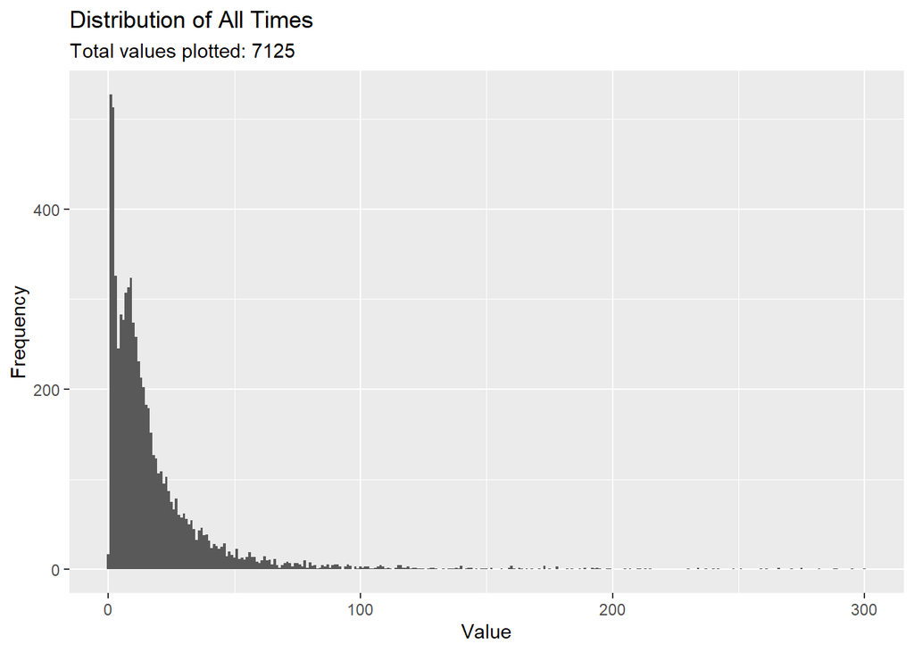

```r
#cut off value for histograms.
LIMIT <- 300 #min:300 , max:2750 (subject to change with more responses)

#bin widths are set to 1 in code.
```

**Histograms for each of the 6 type of questions (6 histograms for 6 question types)**

Q1: When did <event> happen?

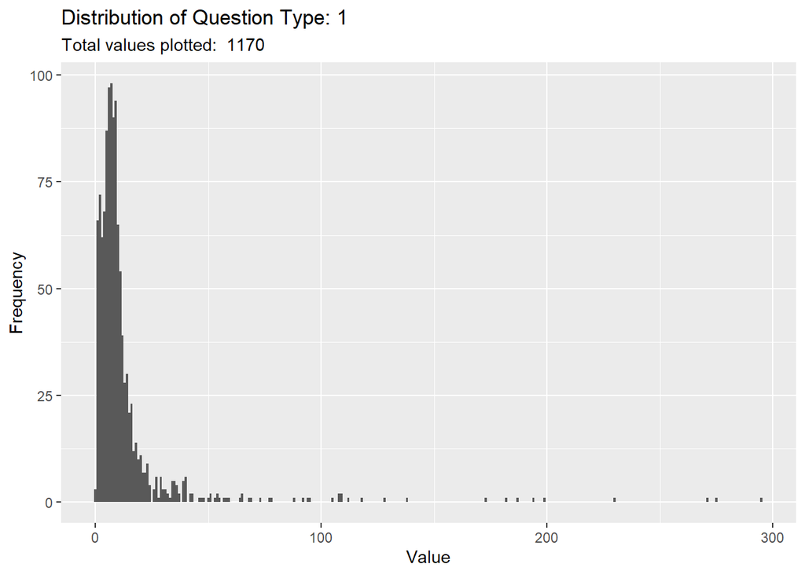

Q2: What happened at <date>?

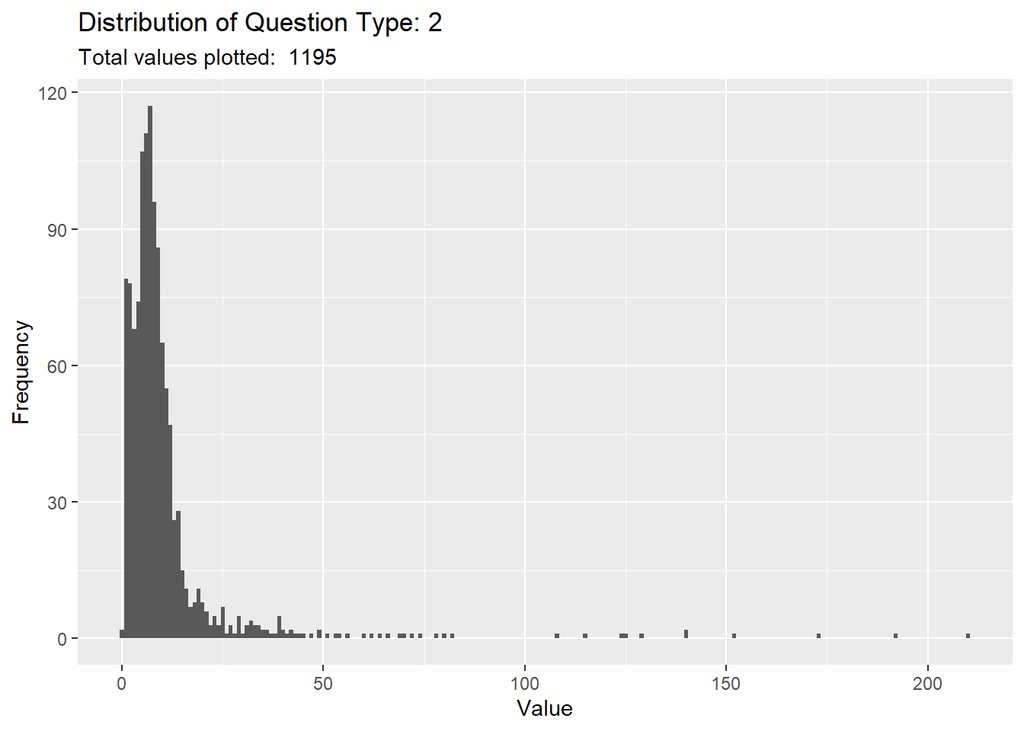

Q3: How much time has passed between <event A> and <event B>?

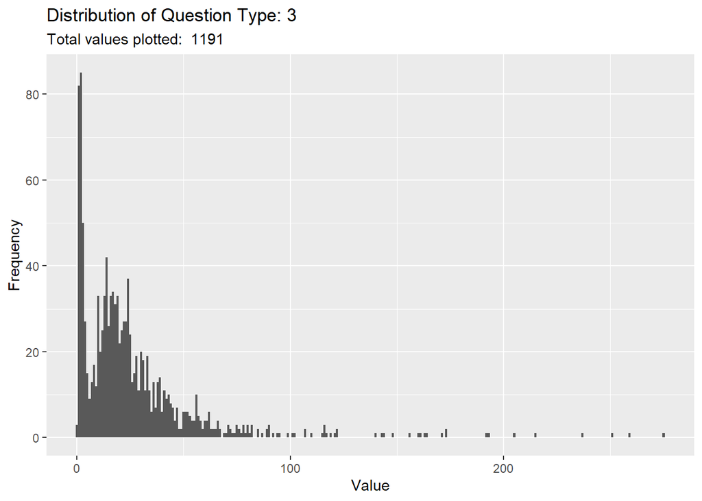

```r
#statistical summary of question type 3:
#skim(all_times_df %>%
  #select(matches("Q3.Time_Page.Submit")) %>%
  #pivot_longer(cols = everything(), names_to = "variable", values_to = "value"))
```

Q4: Does <event A> happen before or after <event B>?

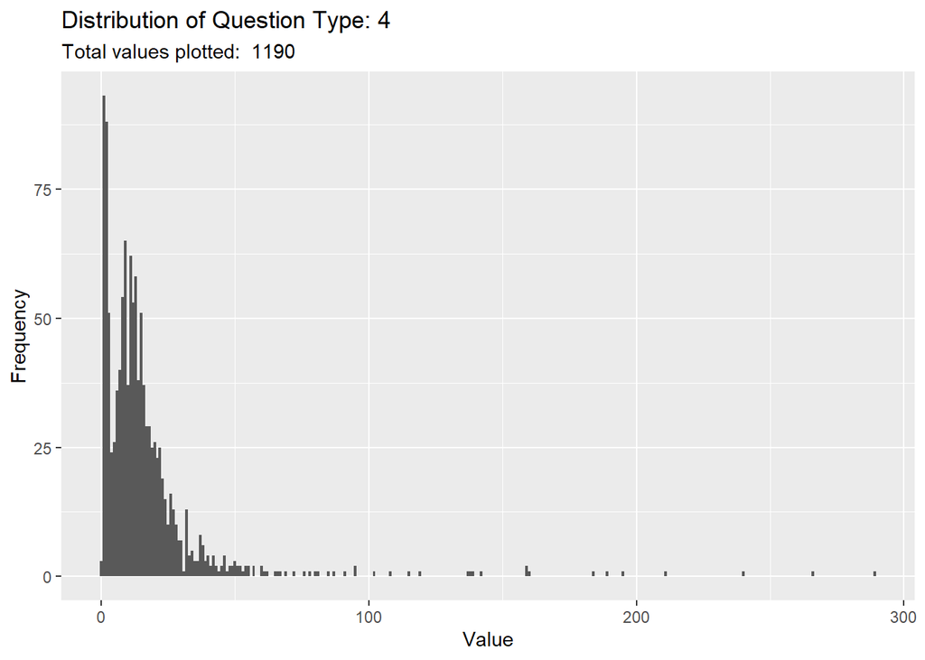

Q5: Is <event B> closer in time to <event A> or <event C>?

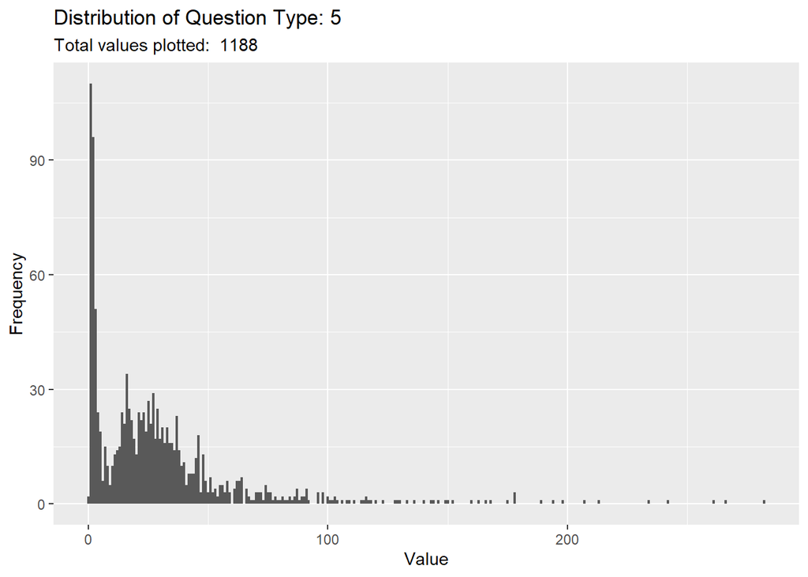

```r
#statistical summary of question type 5:
#skim(all_times_df %>%
  #select(matches("Q5.Time_Page.Submit")) %>%
  #pivot_longer(cols = everything(), names_to = "variable", values_to = "value"))
```

Q6: What two events happened before/ after <event>?

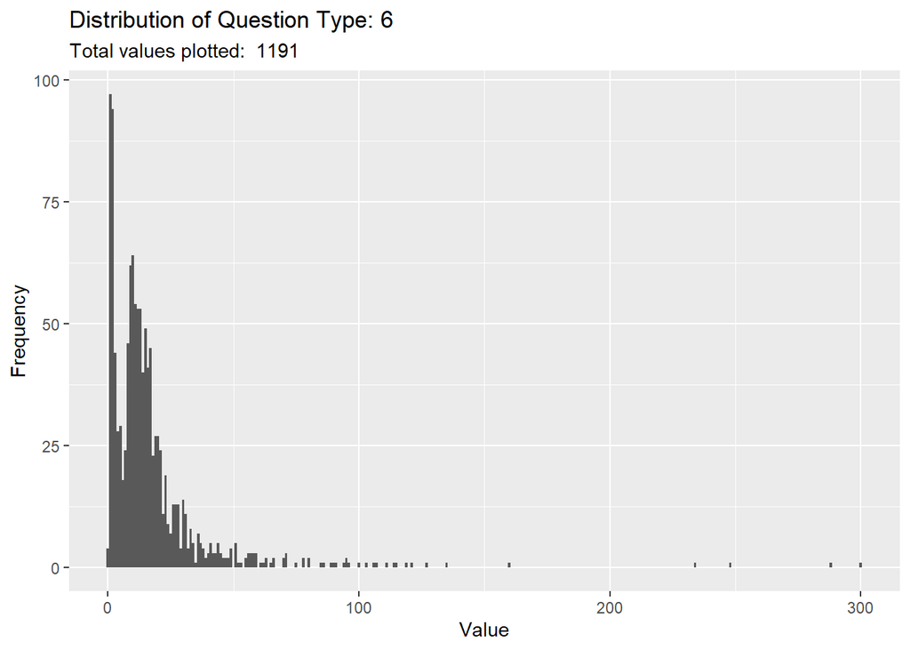

**Response Breakdown** for responses with low response times and low accuracy scores

```r
TIME_LIMIT <- 2 #in seconds
SCORE_BENCHMARK <- 72

# gives subset df with all responses with:
# 1. q3-q6 answered in <= TIME_LIMIT (secs)
# 2. total scores <= BENCHMARK

low_times <- all_times_df %>%
  #filtering out Q1s and Q2s
  dplyr::select(-dplyr::contains("Q1"), -dplyr::contains("Q2")) %>%
    #filtering for time<=TIME_LIMIT
    dplyr::filter(if_any(-1, ~ . <= TIME_LIMIT)) %>%
      #filtering for where SC0 <= BENCHMARK
      dplyr::filter(SC0 <= SCORE_BENCHMARK)

#name format: "low_time[TIMELIMIT]_score[BENCHMARK].csv"
write.csv(low_times, file="low_time2_score72.csv")
```

## Data Analysis by Ques. Accuracy

**How many times was <question> answered correctly?**

**Summary of Accuracy of Each Question**

See `ques_accuracy_summary.csv` for full details.

```
##           count rate pool_size neg_1 neg_2 neg_5 neg_10
## ELR1...Q2    87 0.87       100     6     0     5      2
## ELR1...Q4    92 0.92       100     8     0     0      0
## ELR1...Q1    86 0.86       100     3     0     6      5
## ELR1...Q3    71 0.71       100    18     0     7      4
## ELR1...Q5    55 0.55       100     0     0    12     33
## ELR1...Q6    82 0.82       100     5     4     9      0
```

**Performance Breakdown of Eng - Urdu Responses**

see `urdu_eng_accuracy_summary.csv` for full details

```
##           count rate pool_size neg_1 neg_2 neg_5 neg_10
## ELR1...Q2    14 0.56        25     5     0     4      2
## ELR1...Q4    22 0.88        25     3     0     0      0
## ELR1...Q1    15 0.60        25     3     0     2      5
## ELR1...Q3    15 0.60        25     3     0     4      3
## ELR1...Q5    12 0.48        25     0     0     4      9
## ELR1...Q6    13 0.52        25     4     1     7      0
```

*Distribution of SCORES per participant for Urdu responses*

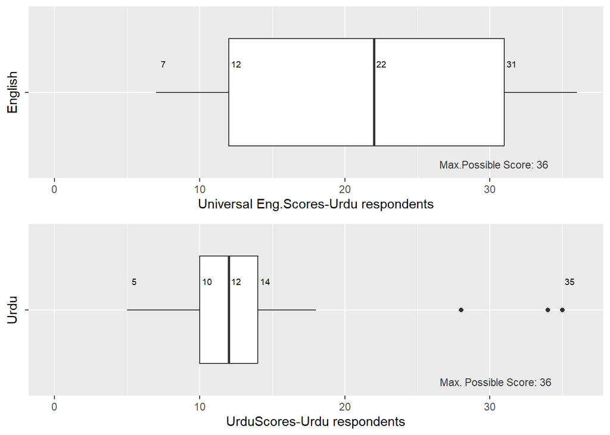

*Distribution of TOTAL TIMES per participant for Urdu responses (MINUTES)*

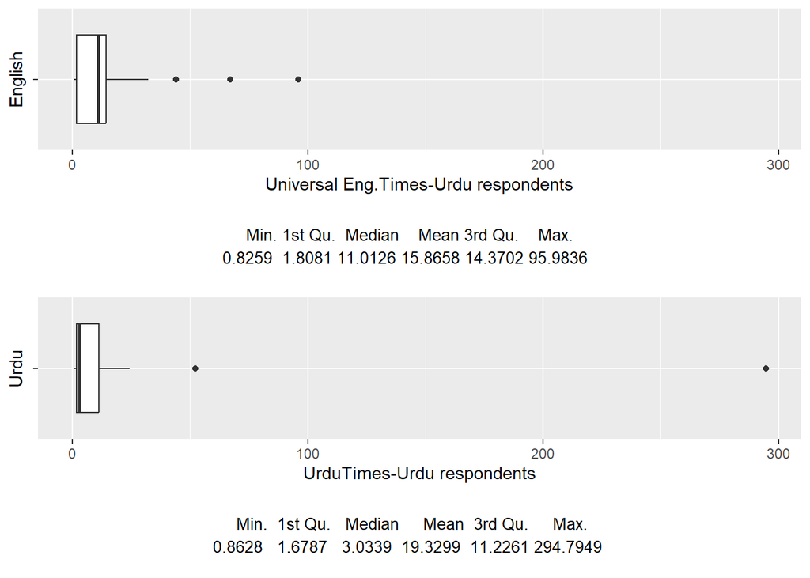

**Performance Breakdown of Eng - Arabic responses**

todo: accuracy summary

*Distribution of SCORES per participant for Arabic responses*

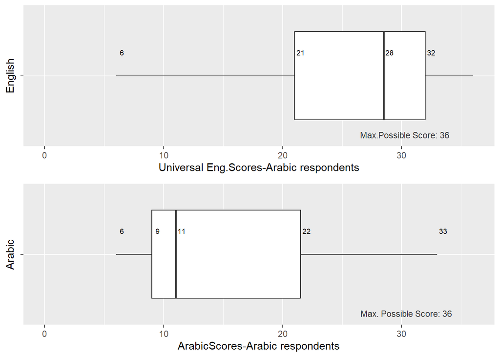

*Distribution of TOTAL TIMES per participant for Arabic responses*

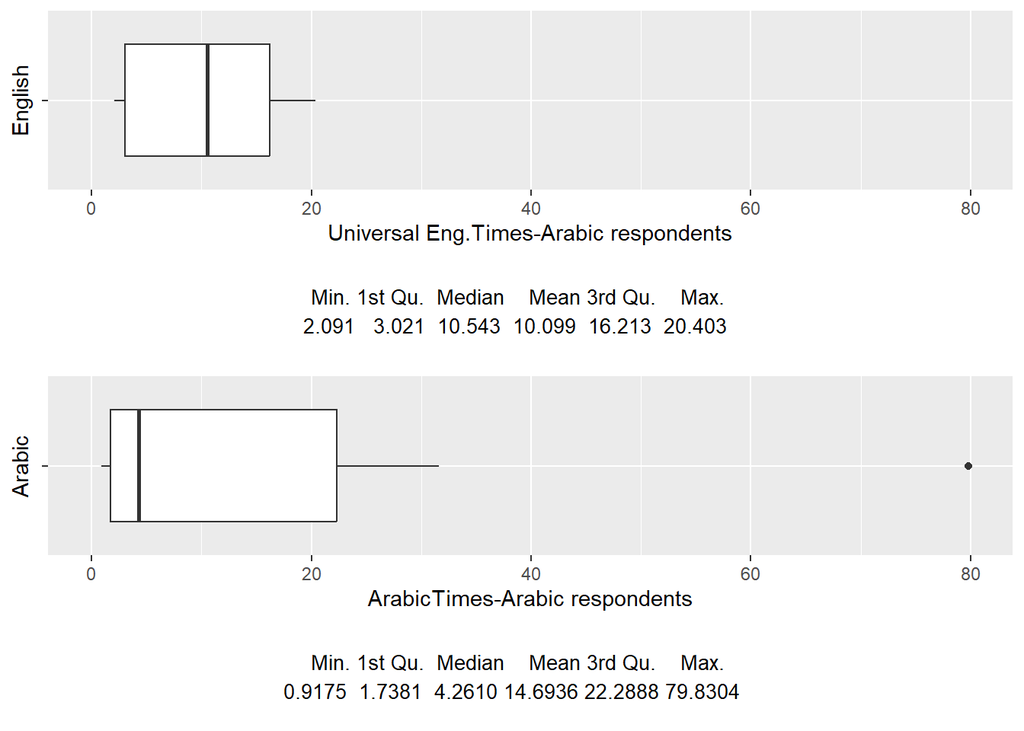

**Performance Breakdown of Eng - English Responses**

todo: accuracy summary

*Distribution of SCORES per participant for English responses*

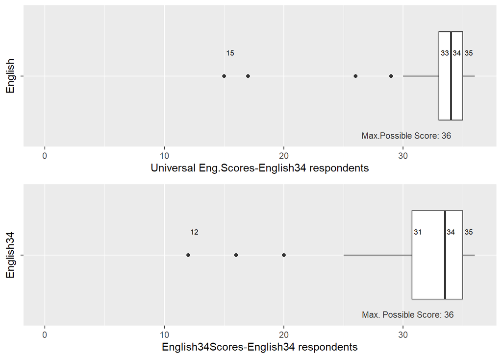

*Distribution of TOTAL TIMES per participant for English responses (MINUTES)*

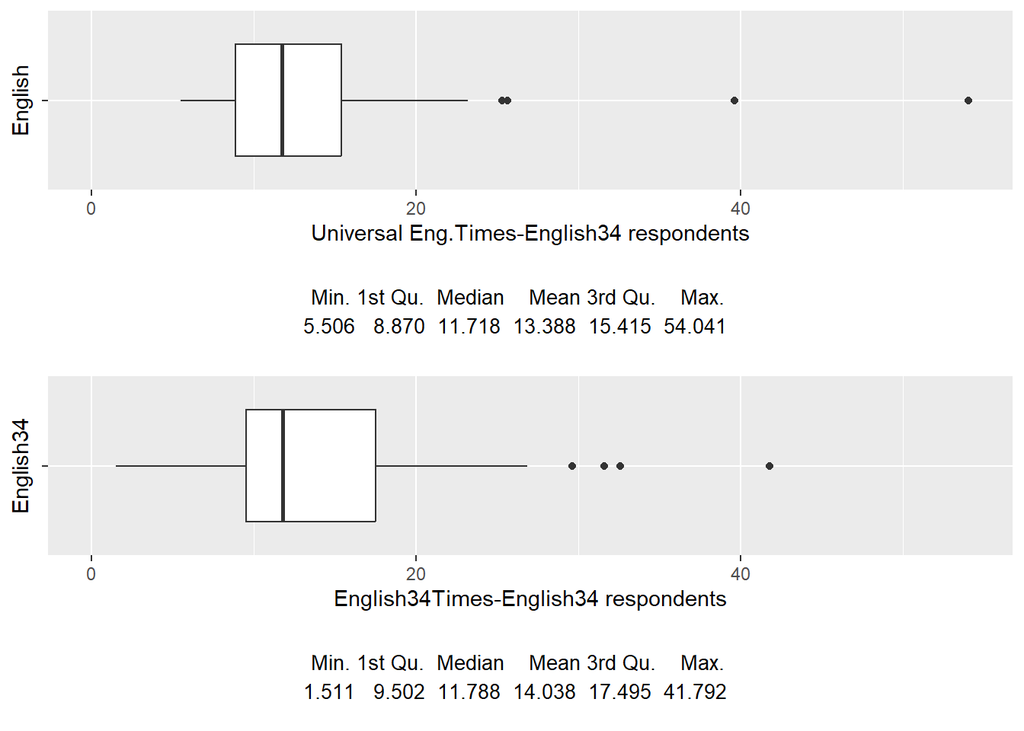